# Regression models trail for Ridership and Gas Price

Rita Li, Jenny Li

2022-10-31

# Research Question and Motivation

We have two research questions, both mainly focusing on the relationship between gas price and ridership. The two research questions are: What is the relationship between gas price and ridership of bus? And how is this relationship different within different types of bus routes? Our motivation for those research questions is due to constantly increasing gas prices in recent years. We are curious how companies,like metro transit, or policy makers would change their strategy to deal with such a situation.

# Data Set Up

## Datasets Read In and Their Description

Ridership data. Ridership our dependent variable in the research question. This dataset on ridership woudl provide us information on the ridership which enables us to build model from it.

```r
ridership<- read_csv("ridershipdata/ridership-route-day-Jan2014-Oct2017.csv")
```

Gas price data. Gas price data is our main independent variable in the research question. This dataset on gas price provide us the trend of gas price which could be compared with the ridership. The data is collected and cleaned by [U.S. Energy Information Administration](https://www.eia.gov/dnav/pet/hist/LeafHandler.ashx?n=PET&s=EMM_EPMRU_PTE_SMN_DPG&f=W).

```r
gas <- read_csv("ridershipdata/Weekly_Minnesota_Regular_Conventional_Retail_Gasoline_Prices.csv", skip = 4)
```

Routes and neighborhood data. This dataset provide information of transit system. Including the route types route ID and other useful information for comparing their responding ridership.

```r
nbhd <- read_csv("ridershipdata/stops_and_neighborhood.xls - TransitStops_Int_ExportTable.csv")
```

## Prepare Gas Dataset

```r
# Calculate the mean for gas price in each month each year
gas_fixed <- gas %>%
  mutate(date = as.Date(`Week of`, "%m/%d/%Y")) %>%
  mutate(gas_price = `Weekly Minnesota Regular Conventional Retail Gasoline Prices Dollars per Gallon`) %>%
  select(date, gas_price) %>%
  mutate(month = month(date),year = year(date)) %>%
  group_by(year,month) %>%
  summarise(gas_price = mean(gas_price,na.rm = TRUE)) %>%
  #filter(year > 2013 & year < 2018) %>%
  ungroup() %>%
  mutate(date = year + (month-1)/12)
```

## Pepare Route Class Dataset

```r
#Clean the routes data
routeclass <- nbhd %>%
  distinct(route, RouteClass)
```

## Join Datasets

```r
# Combine the ridership and the gas price
rider_gas_complete <- ridership %>%
  mutate(date = as.Date(dtDate)) %>%
  mutate(month = month(date),year = year(date)) %>%
  group_by(Route,year,month) %>%
  summarise(riders = sum(Total_Riders),RouteType) %>%
  unique() %>%
  right_join(gas_fixed, by = c("month","year")) %>%
  ungroup()


#Mean ridership data for CoreLoc(one of the bus route types)
CoreLoc <- rider_gas_complete %>%
  right_join(routeclass, by = c("Route" = "route")) %>%
  group_by(RouteClass, year, month) %>%
  summarise(total_riders = mean(riders),gas_price) %>%
  filter(RouteClass == "CoreLoc") %>%
  mutate(date = year + (month-1)/12) %>%
  drop_na() %>%
  unique() %>%
  ungroup()
```

# Models

## CoreLoc

### Visualization of CoreLoc Ridership

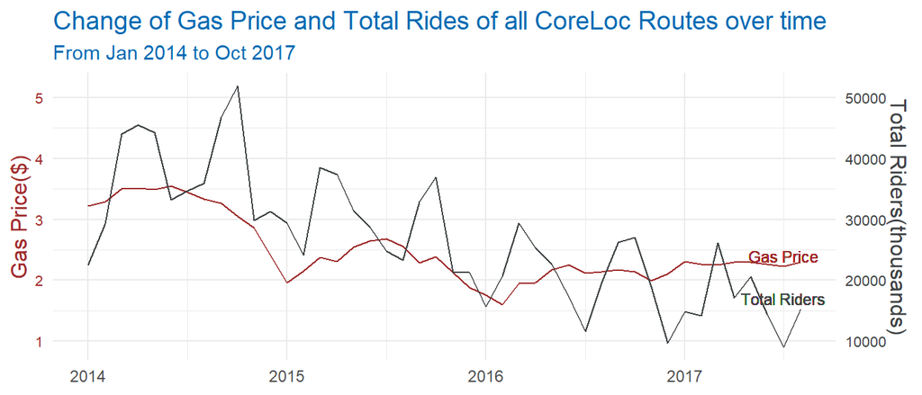

```r
coef <- 10000
CoreLoc %>%
  ggplot(aes(x = date))+
  geom_line(aes(y = gas_price),color = "#9F2C2C")+
  geom_line(aes(y = total_riders/coef-10),color = "#3F4345")+
  scale_y_continuous(
    name = "Gas Price($)",
    sec.axis = sec_axis(trans = ~.*coef-10, name="Total Riders(thousands)"))+
  labs(title = "Change of Gas Price and Total Rides of all CoreLoc Routes over time",
       subtitle = "From Jan 2014 to Oct 2017")+
  geom_text(aes(x = 2017.5, y = 2.4), label = "Gas Price",color = "#9F2C2C",size = 3)+
  geom_text(aes(x = 2017.5, y = 1.7), label = "Total Riders",color = "#3F4345",size = 3)+
  theme_minimal()+
  theme(axis.title.y.left = element_text(color = "#9F2C2C",size = 12),
        axis.title.y.right = element_text(color = "#3F4345",size = 12),
        axis.text.y.left = element_text(color = "#9F2C2C",size = 8),
        axis.text.y.right = element_text(color = "#3F4345",size = 8),
        axis.title.x.bottom = element_blank(),
        plot.title = element_text(color = "#006bb3",size = 14),
        plot.subtitle = element_text(color = "#006bb3"))
```

For the routes catogrized as CoreLoc though the red line representing the gas price is smoother than the black line representing the ridership, the two lines have a similar pattern generally.

### Fit factor(month) + gas_price Model for CoreLoc

```r
CoreLoc <- rider_gas_complete %>%
  right_join(routeclass, by = c("Route" = "route")) %>%
  group_by(RouteClass, year, month) %>%
  summarise(total_riders = mean(riders),gas_price) %>%
  filter(RouteClass == "CoreLoc") %>%
  mutate(date = year + (month-1)/12) %>%
  drop_na() %>%
  unique() %>%
  ungroup()

lm.ride.season <- lm(total_riders ~ factor(month) + gas_price, data = CoreLoc)

CoreLoc$ride_predict <- predict(lm.ride.season)

CoreLoc$remove_season <- CoreLoc$total_riders-CoreLoc$ride_predict

lm.ride.season %>% summary()
```

```
##
## Call:
## lm(formula = total_riders ~ factor(month) + gas_price, data = CoreLoc)
##
## Residuals:
##    Min     1Q Median     3Q    Max
## -11435  -4158    220   3638  13143
##
## Coefficients:
##                 Estimate Std. Error t value Pr(>|t|)
## (Intercept)      91662.0     5326.0  17.210  < 2e-16 ***
## factor(month)2    1228.4     4445.6   0.276  0.78413
## factor(month)3   11213.5     4463.4   2.512  0.01741 *
## factor(month)4    8037.2     4463.4   1.801  0.08149 .
## factor(month)5    5135.8     4484.5   1.145  0.26088
## factor(month)6   -1824.2     4498.2  -0.406  0.68786
## factor(month)7   -4504.3     4483.3  -1.005  0.32283
## factor(month)8    -507.6     4475.4  -0.113  0.91042
## factor(month)9   11357.4     4827.1   2.353  0.02516 *
## factor(month)10  15261.9     4818.8   3.167  0.00345 **
## factor(month)11   2518.4     4801.8   0.524  0.60369
## factor(month)12   2374.2     4812.8   0.493  0.62527
## gas_price        12544.2     1862.8   6.734 1.55e-07 ***
## ---
## Signif. codes:  0 '***' 0.001 '**' 0.01 '*' 0.05 '.' 0.1 ' ' 1
##
## Residual standard error: 6287 on 31 degrees of freedom
## Multiple R-squared:  0.7373, Adjusted R-squared:  0.6356
## F-statistic:  7.25 on 12 and 31 DF,  p-value: 4.35e-06
```

The p-values are small enough combining with few significant p-values indicating that there might exist some correlation between ridership and gas price.

#### Visualization of the results from model

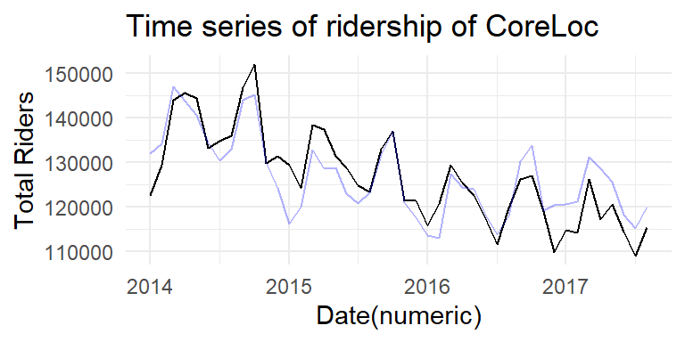

```r
CoreLoc %>%
  ggplot(aes(x = date, y = total_riders)) +
  geom_line()+
  geom_line(aes(y = CoreLoc$ride_predict),color = "blue",alpha = 0.3)+
  theme_minimal()+
  labs(title = "Time series of ridership of CoreLoc",
       x = "Date(numeric)",
       y = "Total Riders")
```

The predicted ridership of CoreLoc from the regression model is very similar to the observations. Thus, we are confident to state that our model is working well.

### Timeseries for CoreLoc Ridership

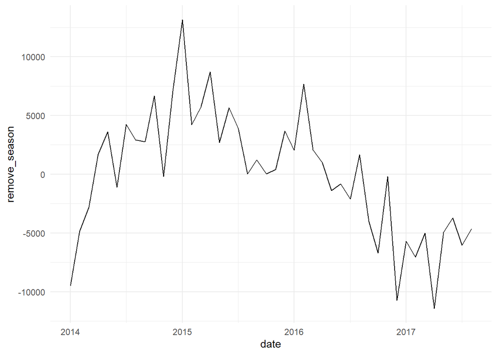

```r
# look at residuals
CoreLoc %>%
  ggplot(aes(x = date, y = remove_season))+
  geom_line()+
  theme_minimal()
```

The residual plot of time series would explain with other evaluaiton later in this session.

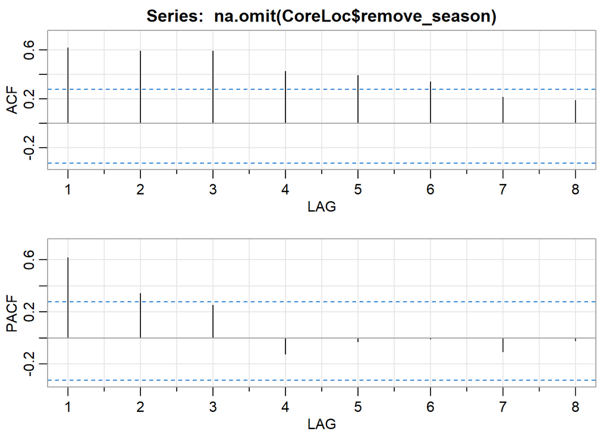

```
##      [,1] [,2] [,3]  [,4]  [,5]  [,6]  [,7]  [,8]
## ACF  0.62 0.59 0.59  0.42  0.39  0.34  0.22  0.19
## PACF 0.62 0.34 0.25 -0.12 -0.03 -0.01 -0.11 -0.02
```

```r
acf2(na.omit(CoreLoc$remove_season))
```

```r
AR2 <- sarima(CoreLoc$remove_season, p = 3, d = 0, q = 0)
```

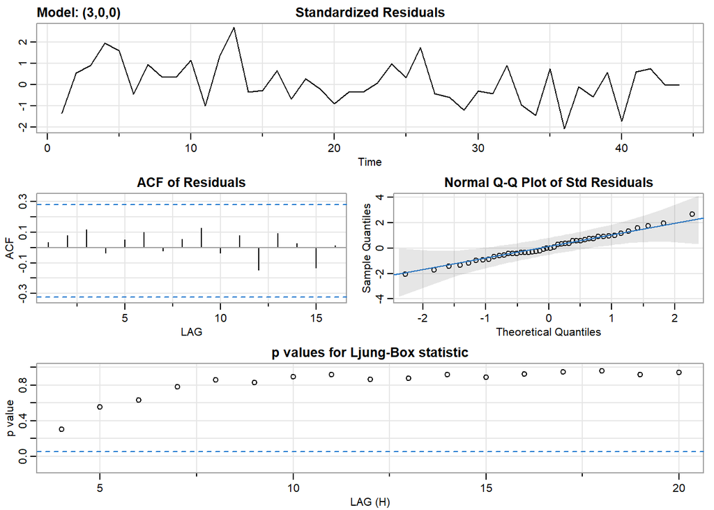

We think our model does a decent job at estimating our data as the ACF of residuals are fairly small, and the p-values for Ljung-Box test are fairly large, which implies our residuals are independent.

## CommExpress

```r
#Mean ridership data for CommExpress(one of the bus route types)
CommExpress <- rider_gas_complete %>%
  right_join(routeclass, by = c("Route" = "route")) %>%
  group_by(RouteClass, year, month) %>%
  summarise(total_riders = mean(riders),gas_price) %>%
  filter(RouteClass == "CommExpress") %>%
  mutate(date = year + (month-1)/12) %>%
  drop_na() %>%
  unique() %>%
  ungroup()
```

### Visualization

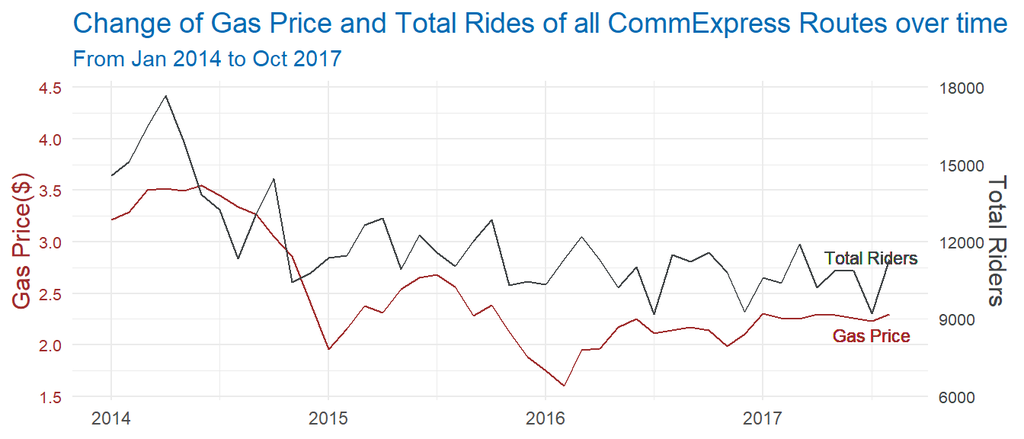

```r
coef <- 4000
CommExpress %>%
  # mutate(gas_price_normalized = (gas_price - mean(gas_price)/sd(gas_price)),
  #        riders_normalized = (total_riders - mean(total_riders))/sd(total_riders)) %>%
  ggplot(aes(x = date))+
  geom_line(aes(y = gas_price),color = "#9F2C2C")+
  geom_line(aes(y = total_riders/coef-1),color = "#3F4345")+
  scale_y_continuous(
    name = "Gas Price($)",
    sec.axis = sec_axis(trans = ~.*coef-1, name="Total Riders"))+
  labs(title = "Change of Gas Price and Total Rides of all CommExpress Routes over time",
       subtitle = "From Jan 2014 to Oct 2017")+
  geom_text(aes(x = 2017.5, y = 2.1), label = "Gas Price",color = "#9F2C2C",size = 3)+
  geom_text(aes(x = 2017.5, y = 2.85), label = "Total Riders",color = "#3F4345",size = 3)+
  theme_minimal()+
  theme(axis.title.y.left = element_text(color = "#9F2C2C",size = 12),
        axis.title.y.right = element_text(color = "#3F4345",size = 12),
        axis.text.y.left = element_text(color = "#9F2C2C",size = 8),
        axis.text.y.right = element_text(color = "#3F4345",size = 8),
        axis.title.x.bottom = element_blank(),
        plot.title = element_text(color = "#006bb3",size = 14),
        plot.subtitle = element_text(color = "#006bb3"))
```

```r
lm.ride.season <- lm(total_riders ~ factor(month) + gas_price, data = CommExpress)

CommExpress$ride_predict <- predict(lm.ride.season)

CommExpress$remove_season <- CommExpress$total_riders-CommExpress$ride_predict

lm.ride.season %>% summary()
```

```
##
## Call:
## lm(formula = total_riders ~ factor(month) + gas_price, data = CommExpress)
##
## Residuals:
##      Min       1Q   Median       3Q      Max
## -2212.96  -510.40    88.19   489.46  1980.32
##
## Coefficients:
##                 Estimate Std. Error t value Pr(>|t|)
## (Intercept)       9547.4      885.0  10.788 5.07e-12 ***
## factor(month)2     287.8      738.7   0.390   0.6995
## factor(month)3    1005.9      741.6   1.356   0.1848
## factor(month)4     722.5      741.6   0.974   0.3375
## factor(month)5    -587.9      745.2  -0.789   0.4362
## factor(month)6    -712.6      747.4  -0.953   0.3477
## factor(month)7   -1757.7      745.0  -2.359   0.0248 *
## factor(month)8   -1165.5      743.6  -1.567   0.1272
## factor(month)9    -322.5      802.1  -0.402   0.6904
## factor(month)10    655.0      800.7   0.818   0.4196
## factor(month)11  -1252.3      797.9  -1.570   0.1267
## factor(month)12  -1084.0      799.7  -1.356   0.1850
## gas_price         2678.0      309.5   8.652 9.03e-10 ***
## ---
## Signif. codes:  0 '***' 0.001 '**' 0.01 '*' 0.05 '.' 0.1 ' ' 1
##
## Residual standard error: 1045 on 31 degrees of freedom
## Multiple R-squared:  0.7791, Adjusted R-squared:  0.6936
## F-statistic:  9.11 on 12 and 31 DF,  p-value: 3.818e-07
```

Same as CoreLoc, the p-values for CommonExpress are small enough combining with few significant p-values indicating that there might exist some correlation between ridership and gas price.

## Other Models

```r
#Mean ridership data for all bus routes
r <- rider_gas_complete %>%
  right_join(routeclass, by = c("Route" = "route")) %>%
  group_by(RouteClass, year, month,Route) %>%
  summarise(total_riders = mean(riders),gas_price) %>%
  mutate(date = year + (month-1)/12) %>%
  drop_na() %>%
  unique() %>%
  ungroup()
```

### Single Vairable Regression of Each Bus Routes, Riders and Gas Price, Visualization of P-values

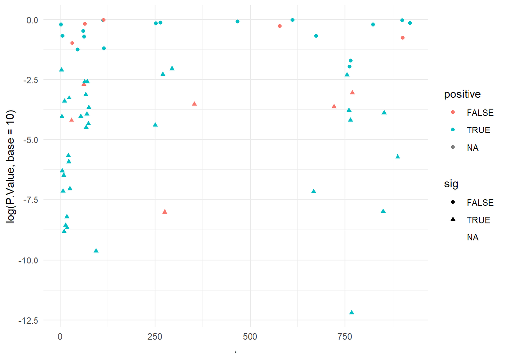

```r
routes <- r$Route %>% unique()

betas <- c()
ses <- c()
tstats <- c()
pvals <- c()

# loop through all routes
a <- 0

for(i in routes){
  rides <- r%>%
    filter(Route == i)
  gasp <- rides$gas_price
  ride <- rides$total_riders

  #fit the linear model
  mod <- lm(ride ~ gasp)
  # get coefficient information
  coefinfo <- tidy(mod)

  a <- a+1
  # record estimate, SE, test stat, and p-value
  betas[a] <- coefinfo$estimate[2]
  ses[a] <- coefinfo$std.error[2]
  tstats[a] <- coefinfo$statistic[2]
  pvals[a] <- coefinfo$p.value[2]
}

mod.results <- routes %>%
  as.data.frame() %>%
  mutate(Estimate = betas,
         Std.Error = ses,
         Test.Statistic = tstats,
         P.Value = pvals)

mod.results %>%
  mutate(sig = ifelse(P.Value <= 0.01,TRUE,FALSE)) %>%
  mutate(positive = ifelse(Estimate > 0, TRUE, FALSE)) %>%
  ggplot(aes(x = ., y = log(P.Value, base=10),shape = sig))+
  geom_point(aes(color = positive))
```

### Z-score of Ridership and Gas Price Linear Regression and Prediction Visualization

```r
justed_data <- rider_gas_complete %>%
  group_by(Route) %>%
  #z-score normalizaiton
  mutate(avg_riders = mean(riders),
         justed_riders = (riders-avg_riders)/sd(riders)) %>%
  mutate(schedules = n()) %>%
  ungroup() %>%
  filter(schedules == 44)

mod.justed <- justed_data %>%
  lm(justed_riders ~ gas_price, data = .)

mod.justed %>% summary()
```

```
##
## Call:
## lm(formula = justed_riders ~ gas_price, data = .)
##
## Residuals:
##     Min      1Q  Median      3Q     Max
## -3.5871 -0.6116  0.0026  0.6370  3.8926
##
## Coefficients:
##             Estimate Std. Error t value Pr(>|t|)
## (Intercept) -1.75366    0.06290  -27.88   <2e-16 ***
## gas_price    0.70513    0.02473   28.51   <2e-16 ***
## ---
## Signif. codes:  0 '***' 0.001 '**' 0.01 '*' 0.05 '.' 0.1 ' ' 1
##
## Residual standard error: 0.9149 on 4838 degrees of freedom
## Multiple R-squared:  0.1439, Adjusted R-squared:  0.1437
## F-statistic: 812.9 on 1 and 4838 DF,  p-value: < 2.2e-16
```

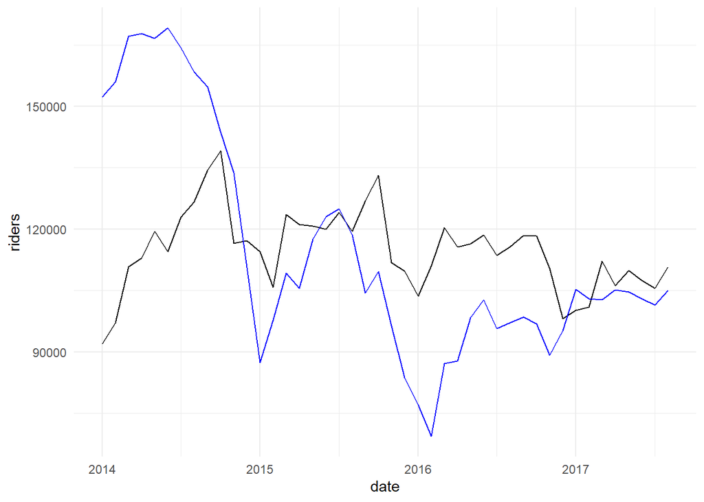

```r
justed_data %>%
  mutate(predict = predict(mod.justed),
         predict_riders = predict * sd(riders) + avg_riders) %>%
  filter(Route == 63) %>%
  ggplot(aes(x = date, y = riders))+
  geom_line()+
  geom_line(aes(y = predict_riders), color = "blue")
```

## Failed Models

```r
ride63 <- rider_gas_complete %>%
  drop_na(riders, date) %>%
  mutate(date_num = year + (month-1)/12) %>%
  count(RouteType)
  ungroup()

lm.season <- lm(riders ~ factor(month), data = ride63)

ride63%>%
  filter(Route == 84|Route == 63) %>%
  ggplot(aes(x = date, y = riders, color = factor(Route))) +
  geom_line()+
  geom_line(aes(y = gas_price*100),color = "black")


lm(riders ~ gas_price+factor(Route), data = ride63) %>%
  summary()

ride63 %>%
  geem(riders ~ gas_price, data = ., id = Route, corstr = "ar1") %>%
  summary()

gas <- ride63 %>%
  filter(Route == 63)

r <- ride63 %>%
  group_by(Route) %>%
  mutate(schedules = n()) %>%
  ungroup() %>%
  filter(schedules == max(schedules))
```

### Z-score and Gas Price Regression for Each Bus Routes and Visualization of P-values.

```r
routes <- justed_data$Route %>% unique()
gasp <- gas$gas_price

#gasp[1] <- 0

betas <- c()
ses <- c()
tstats <- c()
pvals <- c()

# loop through all routes
a <- 0

for(i in routes){
  rides <- justed_data %>%
    filter(Route == i)
  ride <- rides$justed_riders

  #fit the linear model
  mod <- lm(ride ~ gasp)
  # get coefficient information
  coefinfo <- tidy(mod)

  a <- a+1
  # record estimate, SE, test stat, and p-value
  betas[a] <- coefinfo$estimate[2]
  ses[a] <- coefinfo$std.error[2]
  tstats[a] <- coefinfo$statistic[2]
  pvals[a] <- coefinfo$p.value[2]
}

mod.results <- routes %>%
  as.data.frame() %>%
  mutate(Estimate = betas,
         Std.Error = ses,
         Test.Statistic = tstats,
         P.Value = pvals)

mod.results %>%
  mutate(sig = ifelse(P.Value <= 0.05,TRUE,FALSE)) %>%
  mutate(positive = ifelse(Estimate > 0, TRUE, FALSE)) %>%
  ggplot(aes(x = ., y = log(P.Value),shape = sig))+
  geom_point(aes(color = positive))
```

# Visualization

## Shiny App

[shiny app](https://jennylipro.shinyapps.io/routesMap/)

```r
#library
library(shiny)
library(shinyWidgets)
library(rgdal)
library(leaflet)
library (raster)
library(dplyr)
library(sf)
library(tidyverse)
#load data
map <- readOGR("newmap.shp") %>%
  st_as_sf()

#Class name for checkbox
className <- map %>%
  distinct(RouteClass) %>%
  mutate(dum = "1") %>%
  pivot_wider(names_from = RouteClass, values_from = dum)

mychoice = names(className)


ui <- fluidPage(# Application title
  titlePanel("Twin Cities Metro Route Map"),

  sidebarLayout(
    sidebarPanel(
      h4("Please choose route classes to include :"),
      #Select ALL
      checkboxInput("all", "Select All/None"),
      #add checkbox group
      checkboxGroupInput("classSelect", "Route Classes", mychoice)

      # #checkbox list of route class
      # uiOutput("classes_select "),
    ),
    # Show a plot of the generated distribution
    mainPanel(#Dropdown list of routes
      uiOutput("routes_select"),


      #Map
      leafletOutput("routesLeaflet"),)
  ))

# Define server logic required to draw a histogram
server <- function(input, output, session) {
  #update checkbox input
  observe({
    updateCheckboxGroupInput(session,
                             "classSelect",
                             choices = mychoice,
                             #if select all is true, then show all the choices, vice versa
                             selected = if (input$all)
                               mychoice)
  })

  #creat routes dropdown list
  output$routes_select <- renderUI({
    #we want the routes name only appears once
    selectInput("pick_routes", "choose a route:", choices = c(unique(map$route)))
  })


  #create map
  output$routesLeaflet <- renderLeaflet({
    #make it only showed the route selected
    filtered = filter(map, map$route == input$pick_routes)
    #class filter
    filteredClass = filter(map, map$RouteClass %in%  c(input$classSelect))
    #set up color
    factpal <- colorFactor(palette = "Set1", filteredClass$RouteClass)
    #setup map
    routesLeaflet <-
      #map%>%
      leaflet() %>%
      addProviderTiles("CartoDB.Positron",
                       options = providerTileOptions(opacity = 0.8)) %>%
      addPolylines(
        data = filtered,
        color = "navy",
        weight = 3,
        smoothFactor = 0.5,
        opacity = 1.0,
        highlightOptions = highlightOptions(
          color = "cyan",
          weight = 2,
          bringToFront = TRUE
        ),
        popup =  paste("Route: ", map$route, "<br>")
      ) %>%
      addPolylines(
        data = filteredClass,
        color = ~ factpal(RouteClass),
        weight = 1,
        smoothFactor = 0.5,
        opacity = 0.5,
        highlightOptions = highlightOptions(
          color = "yellow",
          weight = 2,
          bringToFront = TRUE
        ),
        popup =  paste("Route: ", map$route, "<br>")
      )


    #call map
    routesLeaflet
  })

}

# Run the application
shinyApp(ui = ui, server = server)
```

# Member Contribution

Rita:

- Generate the models
- Creating the Time Series
- Evaluate and test the model
- Clean and set up datasets

Jenny:

- Generate Shiny App for visualization and set up its dataset
- Creates the outlines
- Generating the narrative and description
- Check and debug the code if needed